# Lesson 02 Pandasを使ってみよう2

### panda-plyのインストールが必要です。

1. コマンドプロンプトで

   ```
   pip install pandas-ply
   ```

2. ctl-Cで止めて、jupyter notebook を再起動する
3. ブラウザーを一度閉じてから立ち上げる

[pandas-ply/README.rst at master · coursera/pandas-ply](https://github.com/coursera/pandas-ply/blob/master/README.rst)  
[pandas-plyを使う - Qiita](http://qiita.com/gg_hatano/items/be4d3e7e969997e40381)  
[Pythonでのデータ操作 - Pandas_plyrを使ってみる - Qiita](http://qiita.com/hik0107/items/3dd260d9939a5e61c4f6)

```python
import pandas as pd
from pandas_ply import install_ply, X, sym_call

install_ply(pd)
```

```python
import pandas as pd
csv_file_name = 'data/WA_Fn-UseC_-HR-Employee-Attrition.csv'

df = pd.read_csv(csv_file_name)
df.head()
```

|  | Age | Attrition | BusinessTravel | DailyRate | Department | DistanceFromHome | Education | EducationField | EmployeeCount | EmployeeNumber | ... | RelationshipSatisfaction | StandardHours | StockOptionLevel | TotalWorkingYears | TrainingTimesLastYear | WorkLifeBalance | YearsAtCompany | YearsInCurrentRole | YearsSinceLastPromotion | YearsWithCurrManager |
| --- | --- | --- | --- | --- | --- | --- | --- | --- | --- | --- | --- | --- | --- | --- | --- | --- | --- | --- | --- | --- | --- |
| 0 | 41 | Yes | Travel_Rarely | 1102 | Sales | 1 | 2 | Life Sciences | 1 | 1 | ... | 1 | 80 | 0 | 8 | 0 | 1 | 6 | 4 | 0 | 5 |
| 1 | 49 | No | Travel_Frequently | 279 | Research & Development | 8 | 1 | Life Sciences | 1 | 2 | ... | 4 | 80 | 1 | 10 | 3 | 3 | 10 | 7 | 1 | 7 |
| 2 | 37 | Yes | Travel_Rarely | 1373 | Research & Development | 2 | 2 | Other | 1 | 4 | ... | 2 | 80 | 0 | 7 | 3 | 3 | 0 | 0 | 0 | 0 |
| 3 | 33 | No | Travel_Frequently | 1392 | Research & Development | 3 | 4 | Life Sciences | 1 | 5 | ... | 3 | 80 | 0 | 8 | 3 | 3 | 8 | 7 | 3 | 0 |
| 4 | 27 | No | Travel_Rarely | 591 | Research & Development | 2 | 1 | Medical | 1 | 7 | ... | 4 | 80 | 1 | 6 | 3 | 3 | 2 | 2 | 2 | 2 |

5 rows × 35 columns

## 1. 列を選ぶ (列名を変更する、条件により値を決めた列を作成する)

### (例) 年齢が40以上の場合はTrueとし、それ以外の場合はFalseとする

```python
df2 = df.ply_select("Department", "Age",
                Distance = X.DistanceFromHome,  ## カラム名を変更できる
                is_adult = (X.Age >= 40)  ## 新しいカラムを定義することも可能になる
                )
df2
```

|  | Department | Age | Distance | is_adult |
| --- | --- | --- | --- | --- |
| 0 | Sales | 41 | 1 | True |
| 1 | Research & Development | 49 | 8 | True |
| 2 | Research & Development | 37 | 2 | False |
| 3 | Research & Development | 33 | 3 | False |
| 4 | Research & Development | 27 | 2 | False |
| 5 | Research & Development | 32 | 2 | False |
| 6 | Research & Development | 59 | 3 | True |
| 7 | Research & Development | 30 | 24 | False |
| 8 | Research & Development | 38 | 23 | False |
| 9 | Research & Development | 36 | 27 | False |
| 10 | Research & Development | 35 | 16 | False |
| 11 | Research & Development | 29 | 15 | False |
| 12 | Research & Development | 31 | 26 | False |
| 13 | Research & Development | 34 | 19 | False |
| 14 | Research & Development | 28 | 24 | False |
| 15 | Research & Development | 29 | 21 | False |
| 16 | Research & Development | 32 | 5 | False |
| 17 | Research & Development | 22 | 16 | False |
| 18 | Sales | 53 | 2 | True |
| 19 | Research & Development | 38 | 2 | False |
| 20 | Research & Development | 24 | 11 | False |
| 21 | Sales | 36 | 9 | False |
| 22 | Research & Development | 34 | 7 | False |
| 23 | Research & Development | 21 | 15 | False |
| 24 | Research & Development | 34 | 6 | False |
| 25 | Research & Development | 53 | 5 | True |
| 26 | Research & Development | 32 | 16 | False |
| 27 | Sales | 42 | 8 | True |
| 28 | Research & Development | 44 | 7 | True |
| 29 | Sales | 46 | 2 | True |
| ... | ... | ... | ... | ... |
| 1440 | Research & Development | 36 | 4 | False |
| 1441 | Research & Development | 56 | 1 | True |
| 1442 | Research & Development | 29 | 1 | False |
| 1443 | Research & Development | 42 | 2 | True |
| 1444 | Research & Development | 56 | 7 | True |
| 1445 | Research & Development | 41 | 28 | True |
| 1446 | Sales | 34 | 28 | False |
| 1447 | Sales | 36 | 15 | False |
| 1448 | Sales | 41 | 3 | True |
| 1449 | Research & Development | 32 | 2 | False |
| 1450 | Human Resources | 35 | 26 | False |
| 1451 | Sales | 38 | 10 | False |
| 1452 | Sales | 50 | 1 | True |
| 1453 | Sales | 36 | 11 | False |
| 1454 | Sales | 45 | 20 | True |
| 1455 | Research & Development | 40 | 2 | True |
| 1456 | Research & Development | 35 | 18 | False |
| 1457 | Research & Development | 40 | 2 | True |
| 1458 | Research & Development | 35 | 1 | False |
| 1459 | Research & Development | 29 | 13 | False |
| 1460 | Research & Development | 29 | 28 | False |
| 1461 | Sales | 50 | 28 | True |
| 1462 | Sales | 39 | 24 | False |
| 1463 | Research & Development | 31 | 5 | False |
| 1464 | Sales | 26 | 5 | False |
| 1465 | Research & Development | 36 | 23 | False |
| 1466 | Research & Development | 39 | 6 | False |
| 1467 | Research & Development | 27 | 4 | False |
| 1468 | Sales | 49 | 2 | True |
| 1469 | Research & Development | 34 | 8 | False |

1470 rows × 4 columns

### (例) 列名を変え、値を100分の1にし、先頭の10行にする。ピリオド(.)で続ける

```python
(df
    .ply_select(
      EducationField=X.EducationField,
      DailyRate_x100 = X.DailyRate / 100
      )
    .head(10)
    )
```

|  | DailyRate_x100 | EducationField |
| --- | --- | --- |
| 0 | 11.02 | Life Sciences |
| 1 | 2.79 | Life Sciences |
| 2 | 13.73 | Other |
| 3 | 13.92 | Life Sciences |
| 4 | 5.91 | Medical |
| 5 | 10.05 | Life Sciences |
| 6 | 13.24 | Medical |
| 7 | 13.58 | Life Sciences |
| 8 | 2.16 | Life Sciences |
| 9 | 12.99 | Medical |

## 2. 列をまとめて、平均値や計数値を得る

### (例) 平均値はmean()、計数値はsize()

```python
dataSummarize = (
    df
    .groupby('Department')
    .ply_select(
      meanAge=X.Age.mean(),
      candidateNum=X.Age.size(),
      )
    )
dataSummarize
```

| Department | meanAge | candidateNum |
| --- | --- | --- |
| Human Resources | 37.809524 | 63 |
| Research & Development | 37.042664 | 961 |
| Sales | 36.542601 | 446 |

## 3. 行を選ぶ (条件に合う行だけを選ぶ)

### ply_where

```python
df.ply_where(X.Age>40,
               X.BusinessTravel == "Travel_Rarely",
               X.EducationField == "Life Sciences"
               )  #全ての条件にAndで満たすデータだけが選択される
```

|  | Age | Attrition | BusinessTravel | DailyRate | Department | DistanceFromHome | Education | EducationField | EmployeeCount | EmployeeNumber | ... | RelationshipSatisfaction | StandardHours | StockOptionLevel | TotalWorkingYears | TrainingTimesLastYear | WorkLifeBalance | YearsAtCompany | YearsInCurrentRole | YearsSinceLastPromotion | YearsWithCurrManager |
| --- | --- | --- | --- | --- | --- | --- | --- | --- | --- | --- | --- | --- | --- | --- | --- | --- | --- | --- | --- | --- | --- |
| 0 | 41 | Yes | Travel_Rarely | 1102 | Sales | 1 | 2 | Life Sciences | 1 | 1 | ... | 1 | 80 | 0 | 8 | 0 | 1 | 6 | 4 | 0 | 5 |
| 18 | 53 | No | Travel_Rarely | 1219 | Sales | 2 | 4 | Life Sciences | 1 | 23 | ... | 3 | 80 | 0 | 31 | 3 | 3 | 25 | 8 | 3 | 7 |
| 50 | 48 | Yes | Travel_Rarely | 626 | Research & Development | 1 | 2 | Life Sciences | 1 | 64 | ... | 4 | 80 | 0 | 23 | 2 | 3 | 1 | 0 | 0 | 0 |
| 63 | 59 | No | Travel_Rarely | 1435 | Sales | 25 | 3 | Life Sciences | 1 | 81 | ... | 4 | 80 | 0 | 28 | 3 | 2 | 21 | 16 | 7 | 9 |
| 67 | 45 | No | Travel_Rarely | 1339 | Research & Development | 7 | 3 | Life Sciences | 1 | 86 | ... | 3 | 80 | 1 | 25 | 2 | 3 | 1 | 0 | 0 | 0 |
| 82 | 55 | No | Travel_Rarely | 111 | Sales | 1 | 2 | Life Sciences | 1 | 106 | ... | 4 | 80 | 1 | 24 | 4 | 3 | 1 | 0 | 1 | 0 |
| 85 | 56 | No | Travel_Rarely | 1400 | Research & Development | 7 | 3 | Life Sciences | 1 | 112 | ... | 1 | 80 | 0 | 37 | 3 | 2 | 6 | 4 | 0 | 2 |
| 87 | 51 | No | Travel_Rarely | 432 | Research & Development | 9 | 4 | Life Sciences | 1 | 116 | ... | 2 | 80 | 2 | 10 | 4 | 3 | 4 | 2 | 0 | 3 |
| 122 | 56 | Yes | Travel_Rarely | 441 | Research & Development | 14 | 4 | Life Sciences | 1 | 161 | ... | 1 | 80 | 3 | 7 | 2 | 3 | 5 | 4 | 4 | 3 |
| 123 | 51 | No | Travel_Rarely | 684 | Research & Development | 6 | 3 | Life Sciences | 1 | 162 | ... | 3 | 80 | 0 | 23 | 5 | 3 | 20 | 18 | 15 | 15 |
| 133 | 41 | No | Travel_Rarely | 802 | Sales | 9 | 1 | Life Sciences | 1 | 176 | ... | 3 | 80 | 1 | 12 | 2 | 3 | 9 | 7 | 0 | 7 |
| 148 | 41 | No | Travel_Rarely | 933 | Research & Development | 9 | 4 | Life Sciences | 1 | 200 | ... | 4 | 80 | 1 | 7 | 2 | 3 | 5 | 0 | 1 | 4 |
| 153 | 45 | No | Travel_Rarely | 194 | Research & Development | 9 | 3 | Life Sciences | 1 | 206 | ... | 3 | 80 | 1 | 20 | 2 | 1 | 17 | 9 | 0 | 15 |
| 163 | 57 | No | Travel_Rarely | 334 | Research & Development | 24 | 2 | Life Sciences | 1 | 223 | ... | 2 | 80 | 1 | 12 | 2 | 1 | 5 | 3 | 1 | 4 |
| 165 | 50 | No | Travel_Rarely | 1452 | Research & Development | 11 | 3 | Life Sciences | 1 | 226 | ... | 2 | 80 | 0 | 21 | 5 | 3 | 5 | 4 | 4 | 4 |
| 166 | 41 | No | Travel_Rarely | 465 | Research & Development | 14 | 3 | Life Sciences | 1 | 227 | ... | 1 | 80 | 1 | 13 | 2 | 3 | 9 | 8 | 1 | 8 |
| 174 | 45 | No | Travel_Rarely | 1268 | Sales | 4 | 2 | Life Sciences | 1 | 240 | ... | 1 | 80 | 1 | 9 | 3 | 4 | 5 | 4 | 0 | 3 |
| 175 | 56 | No | Travel_Rarely | 713 | Research & Development | 8 | 3 | Life Sciences | 1 | 241 | ... | 3 | 80 | 1 | 19 | 3 | 3 | 2 | 2 | 2 | 2 |
| 190 | 52 | No | Travel_Rarely | 699 | Research & Development | 1 | 4 | Life Sciences | 1 | 259 | ... | 1 | 80 | 1 | 34 | 5 | 3 | 33 | 18 | 11 | 9 |
| 213 | 51 | No | Travel_Rarely | 1469 | Research & Development | 8 | 4 | Life Sciences | 1 | 296 | ... | 4 | 80 | 2 | 16 | 5 | 1 | 10 | 9 | 4 | 7 |
| 215 | 41 | No | Travel_Rarely | 896 | Sales | 6 | 3 | Life Sciences | 1 | 298 | ... | 3 | 80 | 0 | 16 | 3 | 3 | 1 | 0 | 0 | 0 |
| 225 | 59 | No | Travel_Rarely | 142 | Research & Development | 3 | 3 | Life Sciences | 1 | 309 | ... | 1 | 80 | 1 | 7 | 6 | 3 | 1 | 0 | 0 | 0 |
| 230 | 52 | No | Travel_Rarely | 1323 | Research & Development | 2 | 3 | Life Sciences | 1 | 316 | ... | 2 | 80 | 0 | 6 | 3 | 2 | 2 | 2 | 2 | 2 |
| 242 | 41 | No | Travel_Rarely | 1411 | Research & Development | 19 | 2 | Life Sciences | 1 | 334 | ... | 1 | 80 | 2 | 17 | 2 | 2 | 1 | 0 | 0 | 0 |
| 253 | 42 | No | Travel_Rarely | 916 | Research & Development | 17 | 2 | Life Sciences | 1 | 347 | ... | 3 | 80 | 0 | 10 | 1 | 3 | 3 | 2 | 0 | 2 |
| 258 | 51 | No | Travel_Rarely | 833 | Research & Development | 1 | 3 | Life Sciences | 1 | 353 | ... | 2 | 80 | 0 | 1 | 0 | 2 | 1 | 0 | 0 | 0 |
| 279 | 50 | No | Travel_Rarely | 797 | Research & Development | 4 | 1 | Life Sciences | 1 | 385 | ... | 1 | 80 | 2 | 28 | 4 | 2 | 10 | 4 | 1 | 6 |
| 281 | 42 | No | Travel_Rarely | 635 | Sales | 1 | 1 | Life Sciences | 1 | 387 | ... | 3 | 80 | 0 | 20 | 3 | 3 | 20 | 16 | 11 | 6 |
| 300 | 41 | No | Travel_Rarely | 334 | Sales | 2 | 4 | Life Sciences | 1 | 410 | ... | 2 | 80 | 0 | 22 | 2 | 3 | 22 | 10 | 0 | 4 |
| 329 | 47 | No | Travel_Rarely | 1482 | Research & Development | 5 | 5 | Life Sciences | 1 | 447 | ... | 2 | 80 | 1 | 21 | 2 | 3 | 3 | 2 | 1 | 1 |
| ... | ... | ... | ... | ... | ... | ... | ... | ... | ... | ... | ... | ... | ... | ... | ... | ... | ... | ... | ... | ... | ... |
| 1194 | 47 | No | Travel_Rarely | 1225 | Sales | 2 | 4 | Life Sciences | 1 | 1676 | ... | 3 | 80 | 3 | 29 | 2 | 3 | 3 | 2 | 1 | 2 |
| 1195 | 49 | No | Travel_Rarely | 809 | Research & Development | 1 | 3 | Life Sciences | 1 | 1677 | ... | 1 | 80 | 0 | 23 | 2 | 3 | 8 | 7 | 0 | 0 |
| 1196 | 41 | No | Travel_Rarely | 1206 | Sales | 23 | 2 | Life Sciences | 1 | 1678 | ... | 4 | 80 | 0 | 21 | 2 | 3 | 2 | 0 | 0 | 2 |
| 1200 | 44 | No | Travel_Rarely | 528 | Human Resources | 1 | 3 | Life Sciences | 1 | 1683 | ... | 1 | 80 | 3 | 8 | 2 | 3 | 2 | 2 | 2 | 2 |
| 1214 | 44 | No | Travel_Rarely | 921 | Research & Development | 2 | 3 | Life Sciences | 1 | 1703 | ... | 2 | 80 | 1 | 9 | 2 | 3 | 8 | 7 | 6 | 7 |
| 1231 | 46 | No | Travel_Rarely | 717 | Research & Development | 13 | 4 | Life Sciences | 1 | 1727 | ... | 4 | 80 | 0 | 19 | 3 | 3 | 10 | 7 | 0 | 9 |
| 1235 | 46 | No | Travel_Rarely | 1277 | Sales | 2 | 3 | Life Sciences | 1 | 1732 | ... | 2 | 80 | 1 | 13 | 5 | 2 | 10 | 6 | 0 | 3 |
| 1243 | 45 | No | Travel_Rarely | 176 | Human Resources | 4 | 3 | Life Sciences | 1 | 1744 | ... | 3 | 80 | 2 | 9 | 2 | 4 | 5 | 0 | 0 | 3 |
| 1266 | 41 | No | Travel_Rarely | 548 | Research & Development | 9 | 4 | Life Sciences | 1 | 1772 | ... | 2 | 80 | 2 | 5 | 2 | 3 | 5 | 3 | 0 | 4 |
| 1269 | 43 | No | Travel_Rarely | 244 | Human Resources | 2 | 3 | Life Sciences | 1 | 1778 | ... | 2 | 80 | 0 | 10 | 5 | 3 | 9 | 7 | 1 | 8 |
| 1294 | 41 | No | Travel_Rarely | 447 | Research & Development | 5 | 3 | Life Sciences | 1 | 1814 | ... | 1 | 80 | 0 | 11 | 3 | 1 | 3 | 2 | 1 | 2 |
| 1303 | 47 | No | Travel_Rarely | 1001 | Research & Development | 4 | 3 | Life Sciences | 1 | 1827 | ... | 3 | 80 | 1 | 28 | 4 | 3 | 22 | 11 | 14 | 10 |
| 1321 | 47 | No | Travel_Rarely | 207 | Research & Development | 9 | 4 | Life Sciences | 1 | 1856 | ... | 3 | 80 | 0 | 7 | 2 | 3 | 2 | 2 | 2 | 0 |
| 1322 | 46 | No | Travel_Rarely | 706 | Research & Development | 2 | 2 | Life Sciences | 1 | 1857 | ... | 3 | 80 | 1 | 12 | 4 | 2 | 9 | 8 | 4 | 7 |
| 1325 | 42 | No | Travel_Rarely | 1142 | Research & Development | 8 | 3 | Life Sciences | 1 | 1860 | ... | 4 | 80 | 0 | 8 | 3 | 3 | 0 | 0 | 0 | 0 |
| 1331 | 48 | No | Travel_Rarely | 1224 | Research & Development | 10 | 3 | Life Sciences | 1 | 1867 | ... | 4 | 80 | 0 | 29 | 3 | 3 | 22 | 10 | 12 | 9 |
| 1333 | 46 | Yes | Travel_Rarely | 1254 | Sales | 10 | 3 | Life Sciences | 1 | 1869 | ... | 3 | 80 | 3 | 14 | 2 | 3 | 8 | 7 | 0 | 7 |
| 1346 | 45 | No | Travel_Rarely | 556 | Research & Development | 25 | 2 | Life Sciences | 1 | 1888 | ... | 4 | 80 | 2 | 10 | 2 | 2 | 9 | 8 | 3 | 8 |
| 1352 | 44 | No | Travel_Rarely | 170 | Research & Development | 1 | 4 | Life Sciences | 1 | 1903 | ... | 4 | 80 | 1 | 10 | 5 | 3 | 2 | 0 | 2 | 2 |
| 1354 | 56 | Yes | Travel_Rarely | 1162 | Research & Development | 24 | 2 | Life Sciences | 1 | 1907 | ... | 4 | 80 | 0 | 5 | 3 | 3 | 4 | 2 | 1 | 0 |
| 1374 | 58 | No | Travel_Rarely | 605 | Sales | 21 | 3 | Life Sciences | 1 | 1938 | ... | 3 | 80 | 1 | 29 | 2 | 2 | 1 | 0 | 0 | 0 |
| 1396 | 53 | Yes | Travel_Rarely | 1168 | Sales | 24 | 4 | Life Sciences | 1 | 1968 | ... | 2 | 80 | 0 | 15 | 2 | 2 | 2 | 2 | 2 | 2 |
| 1397 | 54 | No | Travel_Rarely | 155 | Research & Development | 9 | 2 | Life Sciences | 1 | 1969 | ... | 3 | 80 | 2 | 9 | 6 | 2 | 4 | 3 | 2 | 3 |
| 1399 | 43 | No | Travel_Rarely | 574 | Research & Development | 11 | 3 | Life Sciences | 1 | 1971 | ... | 2 | 80 | 1 | 10 | 1 | 3 | 10 | 9 | 0 | 9 |
| 1419 | 42 | No | Travel_Rarely | 557 | Research & Development | 18 | 4 | Life Sciences | 1 | 1998 | ... | 3 | 80 | 1 | 9 | 3 | 2 | 4 | 3 | 1 | 2 |
| 1420 | 41 | No | Travel_Rarely | 642 | Research & Development | 1 | 3 | Life Sciences | 1 | 1999 | ... | 1 | 80 | 1 | 12 | 3 | 3 | 5 | 3 | 1 | 0 |
| 1443 | 42 | No | Travel_Rarely | 300 | Research & Development | 2 | 3 | Life Sciences | 1 | 2031 | ... | 1 | 80 | 0 | 24 | 2 | 2 | 22 | 6 | 4 | 14 |
| 1445 | 41 | No | Travel_Rarely | 582 | Research & Development | 28 | 4 | Life Sciences | 1 | 2034 | ... | 3 | 80 | 1 | 21 | 3 | 3 | 20 | 7 | 0 | 10 |
| 1448 | 41 | No | Travel_Rarely | 930 | Sales | 3 | 3 | Life Sciences | 1 | 2037 | ... | 3 | 80 | 1 | 14 | 5 | 3 | 5 | 4 | 0 | 4 |
| 1454 | 45 | No | Travel_Rarely | 374 | Sales | 20 | 3 | Life Sciences | 1 | 2046 | ... | 3 | 80 | 0 | 8 | 3 | 3 | 5 | 3 | 0 | 1 |

137 rows × 35 columns

```python
## under 30
(df
    .ply_where(X.Age < 30)
    .head(10)
    )
```

|  | Age | Attrition | BusinessTravel | DailyRate | Department | DistanceFromHome | Education | EducationField | EmployeeCount | EmployeeNumber | ... | RelationshipSatisfaction | StandardHours | StockOptionLevel | TotalWorkingYears | TrainingTimesLastYear | WorkLifeBalance | YearsAtCompany | YearsInCurrentRole | YearsSinceLastPromotion | YearsWithCurrManager |
| --- | --- | --- | --- | --- | --- | --- | --- | --- | --- | --- | --- | --- | --- | --- | --- | --- | --- | --- | --- | --- | --- |
| 4 | 27 | No | Travel_Rarely | 591 | Research & Development | 2 | 1 | Medical | 1 | 7 | ... | 4 | 80 | 1 | 6 | 3 | 3 | 2 | 2 | 2 | 2 |
| 11 | 29 | No | Travel_Rarely | 153 | Research & Development | 15 | 2 | Life Sciences | 1 | 15 | ... | 4 | 80 | 0 | 10 | 3 | 3 | 9 | 5 | 0 | 8 |
| 14 | 28 | Yes | Travel_Rarely | 103 | Research & Development | 24 | 3 | Life Sciences | 1 | 19 | ... | 2 | 80 | 0 | 6 | 4 | 3 | 4 | 2 | 0 | 3 |
| 15 | 29 | No | Travel_Rarely | 1389 | Research & Development | 21 | 4 | Life Sciences | 1 | 20 | ... | 3 | 80 | 1 | 10 | 1 | 3 | 10 | 9 | 8 | 8 |
| 17 | 22 | No | Non-Travel | 1123 | Research & Development | 16 | 2 | Medical | 1 | 22 | ... | 2 | 80 | 2 | 1 | 2 | 2 | 1 | 0 | 0 | 0 |
| 20 | 24 | No | Non-Travel | 673 | Research & Development | 11 | 2 | Other | 1 | 26 | ... | 4 | 80 | 1 | 5 | 5 | 2 | 4 | 2 | 1 | 3 |
| 23 | 21 | No | Travel_Rarely | 391 | Research & Development | 15 | 2 | Life Sciences | 1 | 30 | ... | 4 | 80 | 0 | 0 | 6 | 3 | 0 | 0 | 0 | 0 |
| 34 | 24 | Yes | Travel_Rarely | 813 | Research & Development | 1 | 3 | Medical | 1 | 45 | ... | 1 | 80 | 1 | 6 | 2 | 2 | 2 | 0 | 2 | 0 |
| 41 | 27 | No | Travel_Rarely | 1240 | Research & Development | 2 | 4 | Life Sciences | 1 | 54 | ... | 4 | 80 | 1 | 1 | 6 | 3 | 1 | 0 | 0 | 0 |
| 42 | 26 | Yes | Travel_Rarely | 1357 | Research & Development | 25 | 3 | Life Sciences | 1 | 55 | ... | 3 | 80 | 0 | 1 | 2 | 2 | 1 | 0 | 0 | 1 |

10 rows × 35 columns

## 4. 列名を変更する

[pandas DataFrameの行名・列名の変更 | nkmk log](https://nkmk.github.io/blog/python-pandas-dataframe-rename/)

```python
df.rename(columns={'Age': '年齢', 'Attrition': '自然減', 'BusinessTravel': '出張', 'DailyRate': '日当', \
        'Department': '部署', 'DistanceFromHome': '通勤距離', 'Education': '教育', 'EducationField': '教育領域'}, \
        index={'ONE': 'one'}, inplace=True)
df.head()
```

|  | 年齢 | 自然減 | 出張 | 日当 | 部署 | 通勤距離 | 教育 | 教育領域 | EmployeeCount | EmployeeNumber | ... | RelationshipSatisfaction | StandardHours | StockOptionLevel | TotalWorkingYears | TrainingTimesLastYear | WorkLifeBalance | YearsAtCompany | YearsInCurrentRole | YearsSinceLastPromotion | YearsWithCurrManager |
| --- | --- | --- | --- | --- | --- | --- | --- | --- | --- | --- | --- | --- | --- | --- | --- | --- | --- | --- | --- | --- | --- |
| 0 | 41 | Yes | Travel_Rarely | 1102 | Sales | 1 | 2 | Life Sciences | 1 | 1 | ... | 1 | 80 | 0 | 8 | 0 | 1 | 6 | 4 | 0 | 5 |
| 1 | 49 | No | Travel_Frequently | 279 | Research & Development | 8 | 1 | Life Sciences | 1 | 2 | ... | 4 | 80 | 1 | 10 | 3 | 3 | 10 | 7 | 1 | 7 |
| 2 | 37 | Yes | Travel_Rarely | 1373 | Research & Development | 2 | 2 | Other | 1 | 4 | ... | 2 | 80 | 0 | 7 | 3 | 3 | 0 | 0 | 0 | 0 |
| 3 | 33 | No | Travel_Frequently | 1392 | Research & Development | 3 | 4 | Life Sciences | 1 | 5 | ... | 3 | 80 | 0 | 8 | 3 | 3 | 8 | 7 | 3 | 0 |
| 4 | 27 | No | Travel_Rarely | 591 | Research & Development | 2 | 1 | Medical | 1 | 7 | ... | 4 | 80 | 1 | 6 | 3 | 3 | 2 | 2 | 2 | 2 |

5 rows × 35 columns

## 5. 日本語フォントが使用できるかを確認する

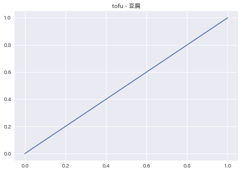

```python
%matplotlib inline
import seaborn as sns
sns.set(font='IPAexGothic')
sns.plt.plot([0,1], [0,1]);  sns.plt.title('tofu - 豆腐')
```

### 上のグラフで「豆腐」の文字が見えない場合

- 日本語フォントの設定のまとめ を実行します。

## 6. 簡単なグラフを描く

```python
dataSummarize = (
    df
    .groupby('部署')
    .ply_select(
      平均通勤距離=X.通勤距離.mean(),
      #candidateNum=X.年齢.size(),
      )
    )
dataSummarize
```

| 部署 | 平均通勤距離 |
| --- | --- |
| Human Resources | 8.698413 |
| Research & Development | 9.144641 |
| Sales | 9.365471 |

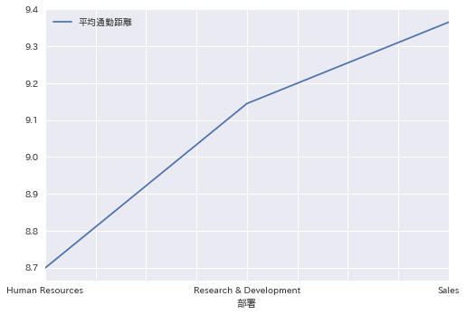

```python
import matplotlib.pyplot as plt
dataSummarize.plot()
plt.show()
```

## 7. ピボットテーブルを試してみる

[pandasでピボットテーブルを扱う · For myself tomorrow](https://tigawa.github.io/blog/2016/07/16/pivot/)

```python
pt = pd.pivot_table(df,
            # 集計したい縦のキー
               index=['部署','出張'],

            # 集計したい横のキー(複数指定可)
               columns='教育領域',

            # 集計したい項目 (指定がなければ、上記のキーになっていない項目)
               values='EmployeeCount',

            # 個数をカウントする。これがないとValuesの平均値になる。
               aggfunc=lambda x : len(x),

            # # NaN を 0埋めする
               fill_value = 0,
            )
pt
```

| 部署 | 教育領域 出張 | Human Resources | Life Sciences | Marketing | Medical | Other | Technical Degree |
| --- | --- | --- | --- | --- | --- | --- | --- |
| Human Resources | Non-Travel | 4 | 1 | 0 | 1 | 0 | 0 |
|  | Travel_Frequently | 6 | 2 | 0 | 2 | 1 | 0 |
|  | Travel_Rarely | 17 | 13 | 0 | 10 | 2 | 4 |
| Research & Development | Non-Travel | 0 | 43 | 0 | 39 | 4 | 11 |
|  | Travel_Frequently | 0 | 91 | 0 | 68 | 10 | 13 |
|  | Travel_Rarely | 0 | 306 | 0 | 256 | 50 | 70 |
| Sales | Non-Travel | 0 | 19 | 12 | 10 | 3 | 3 |
|  | Travel_Frequently | 0 | 30 | 27 | 16 | 3 | 8 |
|  | Travel_Rarely | 0 | 101 | 120 | 62 | 9 | 23 |

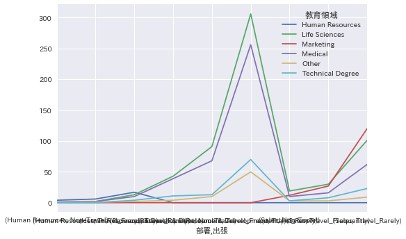

```python
pt.plot()
plt.show()
```

```python
pt = pd.pivot_table(df,
            # 集計したい縦のキー
               index=['部署','出張'],

            # 集計したい横のキー(複数指定可)
               columns=['教育領域', '自然減'],

            # 集計したい項目 (指定がなければ、上記のキーになっていない項目)
               values='EmployeeCount',

            # 個数をカウントする。これがないとValuesの平均値になる。
               aggfunc=lambda x : len(x),

            # # NaN を 0埋めする
               fill_value = 0,
            )
pt
```

| 部署 | 教育領域 自然減 出張 | Human Resources No | Human Resources Yes | Life Sciences No | Life Sciences Yes | Marketing No | Marketing Yes | Medical No | Medical Yes | Other No | Other Yes | Technical Degree No | Technical Degree Yes |
| --- | --- | --- | --- | --- | --- | --- | --- | --- | --- | --- | --- | --- | --- |
| Human Resources | Non-Travel | 4 | 0 | 1 | 0 | 0 | 0 | 1 | 0 | 0 | 0 | 0 | 0 |
|  | Travel_Frequently | 3 | 3 | 1 | 1 | 0 | 0 | 2 | 0 | 1 | 0 | 0 | 0 |
|  | Travel_Rarely | 13 | 4 | 13 | 0 | 0 | 0 | 8 | 2 | 2 | 0 | 2 | 2 |
| Research & Development | Non-Travel | 0 | 0 | 40 | 3 | 0 | 0 | 36 | 3 | 4 | 0 | 9 | 2 |
|  | Travel_Frequently | 0 | 0 | 70 | 21 | 0 | 0 | 57 | 11 | 9 | 1 | 9 | 4 |
|  | Travel_Rarely | 0 | 0 | 271 | 35 | 0 | 0 | 223 | 33 | 44 | 6 | 56 | 14 |
| Sales | Non-Travel | 0 | 0 | 18 | 1 | 11 | 1 | 9 | 1 | 2 | 1 | 3 | 0 |
|  | Travel_Frequently | 0 | 0 | 20 | 10 | 19 | 8 | 14 | 2 | 1 | 2 | 2 | 6 |
|  | Travel_Rarely | 0 | 0 | 83 | 18 | 94 | 26 | 51 | 11 | 8 | 1 | 19 | 4 |

## 8. 行の順序を整える

1. 名称順にする
   - 正順
     - df.reindex(index = natsorted(df.index))
   - 逆順にする
     - df.reindex(index = reversed(natsorted(df.index)))
2. 指定順にする
   1. 順序を得る
      - olist = df.index
        1. olistの要素を並べ変える
        2. df.reindex(index = olist)
- [python - Naturally sorting Pandas DataFrame - Stack Overflow](https://stackoverflow.com/questions/29580978/naturally-sorting-pandas-dataframe)

```python
pt
```

| 部署 | 教育領域 自然減 出張 | Human Resources No | Human Resources Yes | Life Sciences No | Life Sciences Yes | Marketing No | Marketing Yes | Medical No | Medical Yes | Other No | Other Yes | Technical Degree No | Technical Degree Yes |
| --- | --- | --- | --- | --- | --- | --- | --- | --- | --- | --- | --- | --- | --- |
| Human Resources | Non-Travel | 4 | 0 | 1 | 0 | 0 | 0 | 1 | 0 | 0 | 0 | 0 | 0 |
|  | Travel_Frequently | 3 | 3 | 1 | 1 | 0 | 0 | 2 | 0 | 1 | 0 | 0 | 0 |
|  | Travel_Rarely | 13 | 4 | 13 | 0 | 0 | 0 | 8 | 2 | 2 | 0 | 2 | 2 |
| Research & Development | Non-Travel | 0 | 0 | 40 | 3 | 0 | 0 | 36 | 3 | 4 | 0 | 9 | 2 |
|  | Travel_Frequently | 0 | 0 | 70 | 21 | 0 | 0 | 57 | 11 | 9 | 1 | 9 | 4 |
|  | Travel_Rarely | 0 | 0 | 271 | 35 | 0 | 0 | 223 | 33 | 44 | 6 | 56 | 14 |
| Sales | Non-Travel | 0 | 0 | 18 | 1 | 11 | 1 | 9 | 1 | 2 | 1 | 3 | 0 |
|  | Travel_Frequently | 0 | 0 | 20 | 10 | 19 | 8 | 14 | 2 | 1 | 2 | 2 | 6 |
|  | Travel_Rarely | 0 | 0 | 83 | 18 | 94 | 26 | 51 | 11 | 8 | 1 | 19 | 4 |

```python
pt.index
```

```
MultiIndex(levels=[['Human Resources', 'Research & Development', 'Sales'], ['Non-Travel', 'Travel_Frequently', 'Travel_Rarely']],
           labels=[[0, 0, 0, 1, 1, 1, 2, 2, 2], [0, 1, 2, 0, 1, 2, 0, 1, 2]],
           names=['部署', '出張'])
```

```python
from natsort import natsorted
#pt.sort_index(ascending=True, inplace=True)
pt.reindex(index=reversed(natsorted(pt.index)))
```

| 部署 | 教育領域 自然減 出張 | Human Resources No | Human Resources Yes | Life Sciences No | Life Sciences Yes | Marketing No | Marketing Yes | Medical No | Medical Yes | Other No | Other Yes | Technical Degree No | Technical Degree Yes |
| --- | --- | --- | --- | --- | --- | --- | --- | --- | --- | --- | --- | --- | --- |
| Sales | Travel_Rarely | 0 | 0 | 83 | 18 | 94 | 26 | 51 | 11 | 8 | 1 | 19 | 4 |
|  | Travel_Frequently | 0 | 0 | 20 | 10 | 19 | 8 | 14 | 2 | 1 | 2 | 2 | 6 |
|  | Non-Travel | 0 | 0 | 18 | 1 | 11 | 1 | 9 | 1 | 2 | 1 | 3 | 0 |
| Research & Development | Travel_Rarely | 0 | 0 | 271 | 35 | 0 | 0 | 223 | 33 | 44 | 6 | 56 | 14 |
|  | Travel_Frequently | 0 | 0 | 70 | 21 | 0 | 0 | 57 | 11 | 9 | 1 | 9 | 4 |
|  | Non-Travel | 0 | 0 | 40 | 3 | 0 | 0 | 36 | 3 | 4 | 0 | 9 | 2 |
| Human Resources | Travel_Rarely | 13 | 4 | 13 | 0 | 0 | 0 | 8 | 2 | 2 | 0 | 2 | 2 |
|  | Travel_Frequently | 3 | 3 | 1 | 1 | 0 | 0 | 2 | 0 | 1 | 0 | 0 | 0 |
|  | Non-Travel | 4 | 0 | 1 | 0 | 0 | 0 | 1 | 0 | 0 | 0 | 0 | 0 |

```python
index3 = natsorted(pt.index, reverse=True)
index3
```

```
[('Sales', 'Travel_Rarely'),
 ('Sales', 'Travel_Frequently'),
 ('Sales', 'Non-Travel'),
 ('Research & Development', 'Travel_Rarely'),
 ('Research & Development', 'Travel_Frequently'),
 ('Research & Development', 'Non-Travel'),
 ('Human Resources', 'Travel_Rarely'),
 ('Human Resources', 'Travel_Frequently'),
 ('Human Resources', 'Non-Travel')]
```

```python
index3 = [('Sales', 'Travel_Rarely'),
 ('Sales', 'Travel_Frequently'),
 ('Sales', 'Non-Travel'),
 ('Human Resources', 'Travel_Rarely'),
 ('Human Resources', 'Travel_Frequently'),
 ('Human Resources', 'Non-Travel'),
 ('Research & Development', 'Travel_Rarely'),
 ('Research & Development', 'Travel_Frequently'),
 ('Research & Development', 'Non-Travel')]
```

```python
ptx = pt.reindex(index=index3)
ptx
```

| 部署 | 教育領域 自然減 出張 | Human Resources No | Human Resources Yes | Life Sciences No | Life Sciences Yes | Marketing No | Marketing Yes | Medical No | Medical Yes | Other No | Other Yes | Technical Degree No | Technical Degree Yes |
| --- | --- | --- | --- | --- | --- | --- | --- | --- | --- | --- | --- | --- | --- |
| Sales | Travel_Rarely | 0 | 0 | 83 | 18 | 94 | 26 | 51 | 11 | 8 | 1 | 19 | 4 |
|  | Travel_Frequently | 0 | 0 | 20 | 10 | 19 | 8 | 14 | 2 | 1 | 2 | 2 | 6 |
|  | Non-Travel | 0 | 0 | 18 | 1 | 11 | 1 | 9 | 1 | 2 | 1 | 3 | 0 |
| Human Resources | Travel_Rarely | 13 | 4 | 13 | 0 | 0 | 0 | 8 | 2 | 2 | 0 | 2 | 2 |
|  | Travel_Frequently | 3 | 3 | 1 | 1 | 0 | 0 | 2 | 0 | 1 | 0 | 0 | 0 |
|  | Non-Travel | 4 | 0 | 1 | 0 | 0 | 0 | 1 | 0 | 0 | 0 | 0 | 0 |
| Research & Development | Travel_Rarely | 0 | 0 | 271 | 35 | 0 | 0 | 223 | 33 | 44 | 6 | 56 | 14 |
|  | Travel_Frequently | 0 | 0 | 70 | 21 | 0 | 0 | 57 | 11 | 9 | 1 | 9 | 4 |
|  | Non-Travel | 0 | 0 | 40 | 3 | 0 | 0 | 36 | 3 | 4 | 0 | 9 | 2 |

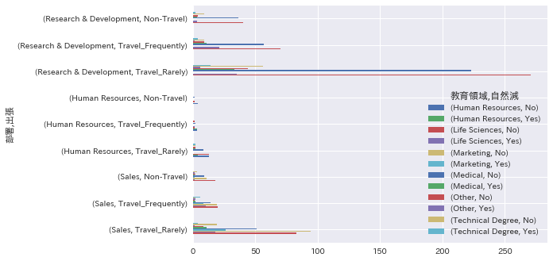

```python
import seaborn as sns
sns.set(font='IPAexGothic')
#ptx = pt.reindex(index=natsorted(pt.index, reverse=True))
ptx = pt.reindex(index=index3)
ptx.plot(kind='barh', stacked=False)
plt.show()
```

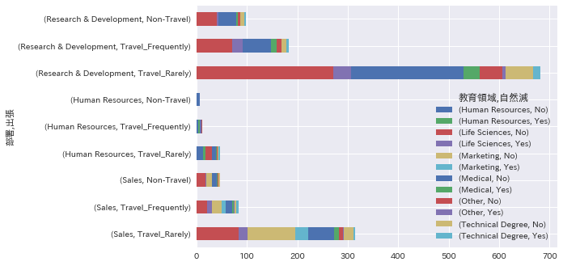

```python
import seaborn as sns
sns.set(font='IPAexGothic')
#ptx = pt.reindex(index=natsorted(pt.index, reverse=True))
ptx = pt.reindex(index=index3)
ptx.plot(kind='barh', stacked=True)
plt.show()
```

```python
df_age = df.sort_values(by=["年齢"], ascending=True)
df_age
```

|  | 年齢 | 自然減 | 出張 | 日当 | 部署 | 通勤距離 | 教育 | 教育領域 | EmployeeCount | EmployeeNumber | ... | RelationshipSatisfaction | StandardHours | StockOptionLevel | TotalWorkingYears | TrainingTimesLastYear | WorkLifeBalance | YearsAtCompany | YearsInCurrentRole | YearsSinceLastPromotion | YearsWithCurrManager |
| --- | --- | --- | --- | --- | --- | --- | --- | --- | --- | --- | --- | --- | --- | --- | --- | --- | --- | --- | --- | --- | --- |
| 1311 | 18 | No | Non-Travel | 1431 | Research & Development | 14 | 3 | Medical | 1 | 1839 | ... | 3 | 80 | 0 | 0 | 4 | 1 | 0 | 0 | 0 | 0 |
| 457 | 18 | Yes | Travel_Frequently | 1306 | Sales | 5 | 3 | Marketing | 1 | 614 | ... | 4 | 80 | 0 | 0 | 3 | 3 | 0 | 0 | 0 | 0 |
| 972 | 18 | No | Non-Travel | 1124 | Research & Development | 1 | 3 | Life Sciences | 1 | 1368 | ... | 3 | 80 | 0 | 0 | 5 | 4 | 0 | 0 | 0 | 0 |
| 301 | 18 | No | Travel_Rarely | 812 | Sales | 10 | 3 | Medical | 1 | 411 | ... | 1 | 80 | 0 | 0 | 2 | 3 | 0 | 0 | 0 | 0 |
| 296 | 18 | Yes | Travel_Rarely | 230 | Research & Development | 3 | 3 | Life Sciences | 1 | 405 | ... | 3 | 80 | 0 | 0 | 2 | 3 | 0 | 0 | 0 | 0 |
| 1153 | 18 | Yes | Travel_Frequently | 544 | Sales | 3 | 2 | Medical | 1 | 1624 | ... | 3 | 80 | 0 | 0 | 2 | 4 | 0 | 0 | 0 | 0 |
| 727 | 18 | No | Non-Travel | 287 | Research & Development | 5 | 2 | Life Sciences | 1 | 1012 | ... | 4 | 80 | 0 | 0 | 2 | 3 | 0 | 0 | 0 | 0 |
| 828 | 18 | Yes | Non-Travel | 247 | Research & Development | 8 | 1 | Medical | 1 | 1156 | ... | 4 | 80 | 0 | 0 | 0 | 3 | 0 | 0 | 0 | 0 |
| 909 | 19 | No | Travel_Rarely | 265 | Research & Development | 25 | 3 | Life Sciences | 1 | 1269 | ... | 4 | 80 | 0 | 1 | 2 | 3 | 1 | 0 | 0 | 1 |
| 422 | 19 | Yes | Travel_Rarely | 489 | Human Resources | 2 | 2 | Technical Degree | 1 | 566 | ... | 3 | 80 | 0 | 1 | 3 | 4 | 1 | 0 | 0 | 0 |
| 688 | 19 | Yes | Travel_Rarely | 419 | Sales | 21 | 3 | Other | 1 | 959 | ... | 2 | 80 | 0 | 1 | 3 | 4 | 1 | 0 | 0 | 0 |
| 127 | 19 | Yes | Travel_Rarely | 528 | Sales | 22 | 1 | Marketing | 1 | 167 | ... | 4 | 80 | 0 | 0 | 2 | 2 | 0 | 0 | 0 | 0 |
| 171 | 19 | Yes | Travel_Frequently | 602 | Sales | 1 | 1 | Technical Degree | 1 | 235 | ... | 1 | 80 | 0 | 1 | 5 | 4 | 0 | 0 | 0 | 0 |
| 177 | 19 | Yes | Travel_Rarely | 303 | Research & Development | 2 | 3 | Life Sciences | 1 | 243 | ... | 3 | 80 | 0 | 1 | 3 | 2 | 1 | 0 | 1 | 0 |
| 892 | 19 | Yes | Non-Travel | 504 | Research & Development | 10 | 3 | Medical | 1 | 1248 | ... | 2 | 80 | 0 | 1 | 2 | 4 | 1 | 1 | 0 | 0 |
| 149 | 19 | No | Travel_Rarely | 1181 | Research & Development | 3 | 1 | Medical | 1 | 201 | ... | 4 | 80 | 0 | 1 | 3 | 3 | 1 | 0 | 0 | 0 |
| 853 | 19 | No | Travel_Rarely | 645 | Research & Development | 9 | 2 | Life Sciences | 1 | 1193 | ... | 3 | 80 | 0 | 1 | 4 | 3 | 1 | 1 | 0 | 0 |
| 689 | 20 | Yes | Travel_Rarely | 129 | Research & Development | 4 | 3 | Technical Degree | 1 | 960 | ... | 2 | 80 | 0 | 1 | 2 | 3 | 1 | 0 | 0 | 0 |
| 876 | 20 | No | Travel_Rarely | 654 | Sales | 21 | 3 | Marketing | 1 | 1226 | ... | 4 | 80 | 0 | 2 | 2 | 3 | 2 | 1 | 2 | 2 |
| 662 | 20 | Yes | Travel_Rarely | 500 | Sales | 2 | 3 | Medical | 1 | 922 | ... | 4 | 80 | 0 | 2 | 3 | 2 | 2 | 2 | 0 | 2 |
| 776 | 20 | Yes | Travel_Frequently | 769 | Sales | 9 | 3 | Marketing | 1 | 1077 | ... | 2 | 80 | 0 | 2 | 3 | 3 | 2 | 2 | 0 | 2 |
| 856 | 20 | No | Travel_Rarely | 805 | Research & Development | 3 | 3 | Life Sciences | 1 | 1198 | ... | 1 | 80 | 0 | 2 | 2 | 2 | 2 | 2 | 1 | 2 |
| 487 | 20 | No | Travel_Rarely | 959 | Research & Development | 1 | 3 | Life Sciences | 1 | 657 | ... | 4 | 80 | 0 | 1 | 0 | 4 | 1 | 0 | 0 | 0 |
| 513 | 20 | Yes | Travel_Rarely | 1362 | Research & Development | 10 | 1 | Medical | 1 | 701 | ... | 4 | 80 | 0 | 1 | 5 | 3 | 1 | 0 | 1 | 1 |
| 1178 | 20 | No | Travel_Rarely | 1141 | Sales | 2 | 3 | Medical | 1 | 1657 | ... | 1 | 80 | 0 | 2 | 3 | 3 | 2 | 2 | 2 | 2 |
| 1197 | 20 | No | Travel_Rarely | 727 | Sales | 9 | 1 | Life Sciences | 1 | 1680 | ... | 1 | 80 | 0 | 2 | 3 | 3 | 2 | 2 | 0 | 2 |
| 102 | 20 | Yes | Travel_Frequently | 871 | Research & Development | 6 | 3 | Life Sciences | 1 | 137 | ... | 2 | 80 | 0 | 1 | 5 | 3 | 1 | 0 | 1 | 0 |
| 731 | 20 | Yes | Travel_Rarely | 1097 | Research & Development | 11 | 3 | Medical | 1 | 1016 | ... | 1 | 80 | 0 | 1 | 2 | 3 | 1 | 0 | 0 | 0 |
| 815 | 21 | No | Travel_Rarely | 984 | Research & Development | 1 | 1 | Technical Degree | 1 | 1131 | ... | 3 | 80 | 0 | 2 | 6 | 4 | 2 | 2 | 2 | 2 |
| 370 | 21 | Yes | Travel_Rarely | 156 | Sales | 12 | 3 | Life Sciences | 1 | 494 | ... | 4 | 80 | 0 | 1 | 0 | 3 | 1 | 0 | 0 | 0 |
| ... | ... | ... | ... | ... | ... | ... | ... | ... | ... | ... | ... | ... | ... | ... | ... | ... | ... | ... | ... | ... | ... |
| 163 | 57 | No | Travel_Rarely | 334 | Research & Development | 24 | 2 | Life Sciences | 1 | 223 | ... | 2 | 80 | 1 | 12 | 2 | 1 | 5 | 3 | 1 | 4 |
| 1374 | 58 | No | Travel_Rarely | 605 | Sales | 21 | 3 | Life Sciences | 1 | 1938 | ... | 3 | 80 | 1 | 29 | 2 | 2 | 1 | 0 | 0 | 0 |
| 1301 | 58 | No | Non-Travel | 350 | Sales | 2 | 3 | Medical | 1 | 1824 | ... | 4 | 80 | 1 | 37 | 0 | 2 | 16 | 9 | 14 | 14 |
| 308 | 58 | No | Non-Travel | 390 | Research & Development | 1 | 4 | Life Sciences | 1 | 422 | ... | 4 | 80 | 1 | 12 | 2 | 3 | 5 | 3 | 1 | 2 |
| 700 | 58 | Yes | Travel_Rarely | 289 | Research & Development | 2 | 3 | Technical Degree | 1 | 977 | ... | 1 | 80 | 0 | 7 | 4 | 3 | 1 | 0 | 0 | 0 |
| 966 | 58 | Yes | Travel_Rarely | 601 | Research & Development | 7 | 4 | Medical | 1 | 1360 | ... | 4 | 80 | 0 | 31 | 0 | 2 | 10 | 9 | 5 | 9 |
| 98 | 58 | No | Travel_Rarely | 682 | Sales | 10 | 4 | Medical | 1 | 131 | ... | 3 | 80 | 0 | 38 | 1 | 2 | 37 | 10 | 1 | 8 |
| 1310 | 58 | No | Travel_Frequently | 1216 | Research & Development | 15 | 4 | Life Sciences | 1 | 1837 | ... | 2 | 80 | 0 | 23 | 3 | 3 | 2 | 2 | 2 | 2 |
| 1009 | 58 | No | Travel_Rarely | 1055 | Research & Development | 1 | 3 | Medical | 1 | 1423 | ... | 3 | 80 | 1 | 32 | 3 | 3 | 9 | 8 | 1 | 5 |
| 938 | 58 | No | Travel_Rarely | 848 | Research & Development | 23 | 4 | Life Sciences | 1 | 1308 | ... | 4 | 80 | 2 | 2 | 3 | 3 | 2 | 2 | 2 | 2 |
| 157 | 58 | No | Travel_Rarely | 1145 | Research & Development | 9 | 3 | Medical | 1 | 214 | ... | 2 | 80 | 1 | 9 | 3 | 2 | 1 | 0 | 0 | 0 |
| 674 | 58 | No | Travel_Rarely | 1272 | Research & Development | 5 | 3 | Technical Degree | 1 | 940 | ... | 4 | 80 | 1 | 24 | 3 | 3 | 6 | 0 | 0 | 4 |
| 126 | 58 | Yes | Travel_Rarely | 147 | Research & Development | 23 | 4 | Medical | 1 | 165 | ... | 4 | 80 | 1 | 40 | 3 | 2 | 40 | 10 | 15 | 6 |
| 595 | 58 | Yes | Travel_Rarely | 286 | Research & Development | 2 | 4 | Life Sciences | 1 | 825 | ... | 4 | 80 | 0 | 40 | 2 | 3 | 31 | 15 | 13 | 8 |
| 660 | 58 | Yes | Travel_Frequently | 781 | Research & Development | 2 | 1 | Life Sciences | 1 | 918 | ... | 4 | 80 | 1 | 3 | 3 | 2 | 1 | 0 | 0 | 0 |
| 743 | 59 | No | Travel_Rarely | 715 | Research & Development | 2 | 3 | Life Sciences | 1 | 1032 | ... | 1 | 80 | 0 | 30 | 4 | 3 | 5 | 3 | 4 | 3 |
| 6 | 59 | No | Travel_Rarely | 1324 | Research & Development | 3 | 3 | Medical | 1 | 10 | ... | 1 | 80 | 3 | 12 | 3 | 2 | 1 | 0 | 0 | 0 |
| 758 | 59 | No | Travel_Rarely | 1089 | Sales | 1 | 2 | Technical Degree | 1 | 1048 | ... | 3 | 80 | 1 | 14 | 1 | 1 | 6 | 4 | 0 | 4 |
| 897 | 59 | No | Travel_Rarely | 326 | Sales | 3 | 3 | Life Sciences | 1 | 1254 | ... | 4 | 80 | 0 | 13 | 2 | 3 | 6 | 1 | 0 | 5 |
| 919 | 59 | No | Travel_Rarely | 1429 | Research & Development | 18 | 4 | Medical | 1 | 1283 | ... | 4 | 80 | 0 | 25 | 6 | 2 | 9 | 7 | 5 | 4 |
| 225 | 59 | No | Travel_Rarely | 142 | Research & Development | 3 | 3 | Life Sciences | 1 | 309 | ... | 1 | 80 | 1 | 7 | 6 | 3 | 1 | 0 | 0 | 0 |
| 70 | 59 | No | Travel_Frequently | 1225 | Sales | 1 | 1 | Life Sciences | 1 | 91 | ... | 4 | 80 | 0 | 20 | 2 | 2 | 4 | 3 | 1 | 3 |
| 105 | 59 | No | Non-Travel | 1420 | Human Resources | 2 | 4 | Human Resources | 1 | 140 | ... | 4 | 80 | 1 | 30 | 3 | 3 | 3 | 2 | 2 | 2 |
| 63 | 59 | No | Travel_Rarely | 1435 | Sales | 25 | 3 | Life Sciences | 1 | 81 | ... | 4 | 80 | 0 | 28 | 3 | 2 | 21 | 16 | 7 | 9 |
| 232 | 59 | No | Travel_Rarely | 818 | Human Resources | 6 | 2 | Medical | 1 | 321 | ... | 4 | 80 | 0 | 7 | 2 | 2 | 2 | 2 | 2 | 2 |
| 536 | 60 | No | Travel_Rarely | 1179 | Sales | 16 | 4 | Marketing | 1 | 732 | ... | 4 | 80 | 0 | 10 | 1 | 3 | 2 | 2 | 2 | 2 |
| 427 | 60 | No | Travel_Frequently | 1499 | Sales | 28 | 3 | Marketing | 1 | 573 | ... | 4 | 80 | 0 | 22 | 5 | 4 | 18 | 13 | 13 | 11 |
| 411 | 60 | No | Travel_Rarely | 422 | Research & Development | 7 | 3 | Life Sciences | 1 | 549 | ... | 4 | 80 | 0 | 33 | 5 | 1 | 29 | 8 | 11 | 10 |
| 879 | 60 | No | Travel_Rarely | 696 | Sales | 7 | 4 | Marketing | 1 | 1233 | ... | 2 | 80 | 1 | 12 | 3 | 3 | 11 | 7 | 1 | 9 |
| 1209 | 60 | No | Travel_Rarely | 370 | Research & Development | 1 | 4 | Medical | 1 | 1697 | ... | 3 | 80 | 1 | 19 | 2 | 4 | 1 | 0 | 0 | 0 |

1470 rows × 35 columns

```python
dataSummarize
```

| 部署 | 平均通勤距離 |
| --- | --- |
| Human Resources | 8.698413 |
| Research & Development | 9.144641 |
| Sales | 9.365471 |

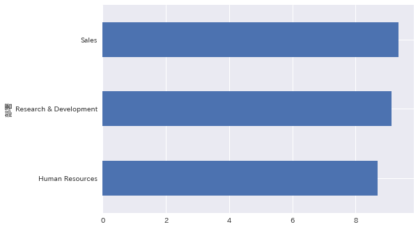

```python
dataSummarize.plot(kind='barh', legend=False)
```

```python
dataSummarize_r = dataSummarize.sort_values(by=["平均通勤距離"], ascending=False)
dataSummarize_r
```

| 部署 | 平均通勤距離 |
| --- | --- |
| Sales | 9.365471 |
| Research & Development | 9.144641 |
| Human Resources | 8.698413 |

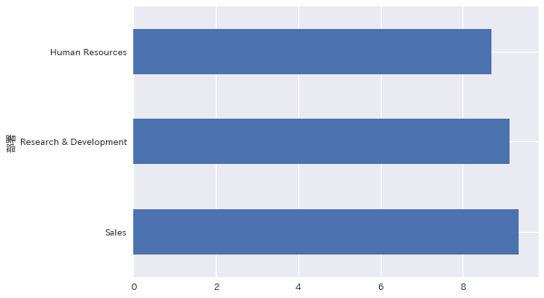

```python
dataSummarize_r.plot(kind='barh', legend=False)
```